# Prediction of Heart stroke

## Phase 1: Data Preparation & Visualization

#### Group Name: Group 14

#### Name(s) & ID(s) of Group Members:

- **Aarthi Vijayakumar(s3958151)**
- **Krishnakanth Srikanth(s3959200)**
- **Antony Rosario John Peter (s3940203)**
- Introduction
  - Dataset Source
  - Dataset Details
  - Dataset Features
  - Target Feature
- Goals and Objectives
- Data Cleaning and Preprocessing
- Data Exploration and Visualization
  - Univariate Visualization
  - Bivariate Visualization
  - Multivariate Visualization
- Summary and Conclusion
- Literature Review
- References

## Introduction

### Dataset Source

The heart rate dataset used in this study is sourced from Kaggle (Mirza_Hasnine, 2023). This dataset contains the risk factors that can contribute to a heart stroke.

### Dataset Details

This dataset is about the risk factors that plays a major role in causing a heart disease to a person.

The dataset contains information about the risk factors like smoking, increase hypertension, total cholesterol levels and also about the glucose levels. Additional features included in this dataset are the age, BMI, gender, education level of the person, number of cigarettes smoked per day(if the person is smoking), BP medicines taken, systolic and diastolic blood pressure levels, heart rate, if the person has diabetes and if they have any prevalence of stroke. These features appear to be suffice for us to make an attempt for predictive modeling of heart disease as a classification problem.

This dataset has a total of 16 features and 4238 observations.

```python
# Importing libraries
import warnings
warnings.filterwarnings("ignore") # To ignore warnings
import pandas as pd
pd.set_option('display.max_columns', None) # Display all columns
import numpy as np
import matplotlib.pyplot as plt
import seaborn as sns
```

```python
# Importing dataset
heart_data = pd.read_csv('Phase1_Group14.csv')
```

```python
# Sampling the dataset to display 10 rows
heart_data.sample(n=10,random_state=25)
```

|  | Gender | age | education | currentSmoker | cigsPerDay | BPMeds | prevalentStroke | prevalentHyp | diabetes | totChol | sysBP | diaBP | BMI | heartRate | glucose | Heart_ stroke |
| --- | --- | --- | --- | --- | --- | --- | --- | --- | --- | --- | --- | --- | --- | --- | --- | --- |
| 1158 | Female | 46 | graduate | 1 | 5.0 | 0.0 | no | 0 | 0 | 291.0 | 107.5 | 65.0 | 24.10 | 82.0 | 78.0 | No |
| 3092 | Female | 60 | primaryschool | 0 | 0.0 | 0.0 | no | 1 | 0 | 298.0 | 133.0 | 89.0 | 25.09 | 83.0 | 81.0 | No |
| 1371 | Female | 55 | primaryschool | 0 | 0.0 | 0.0 | no | 1 | 0 | 340.0 | 140.0 | 83.0 | 26.18 | 75.0 | 83.0 | No |
| 1596 | Male | 45 | graduate | 1 | 30.0 | 0.0 | no | 1 | 0 | 270.0 | 140.0 | 94.0 | 30.39 | 75.0 | 80.0 | No |
| 3471 | Female | 45 | graduate | 0 | 0.0 | 0.0 | no | 0 | 0 | 230.0 | 128.5 | 87.5 | 23.75 | 82.0 | 62.0 | No |
| 2607 | Female | 57 | uneducated | 0 | 0.0 | 0.0 | no | 1 | 0 | 382.0 | 133.0 | 77.0 | 24.27 | 75.0 | 81.0 | No |
| 697 | Female | 46 | uneducated | 1 | 20.0 | 0.0 | no | 0 | 0 | 203.0 | 117.0 | 68.0 | 21.50 | 110.0 | 85.0 | No |
| 2837 | Male | 40 | graduate | 1 | 15.0 | 0.0 | no | 0 | 0 | 203.0 | 123.0 | 82.0 | 24.74 | 75.0 | 78.0 | No |
| 2998 | Male | 44 | uneducated | 0 | 0.0 | 0.0 | no | 0 | 0 | 234.0 | 135.0 | 88.0 | 25.65 | 52.0 | 83.0 | No |
| 2529 | Female | 39 | postgraduate | 0 | 0.0 | 0.0 | no | 0 | 0 | 229.0 | 119.0 | 63.5 | NaN | 76.0 | 83.0 | No |

### Dataset Features

The features in our dataset are described in the table below.

```python
from tabulate import tabulate

table = [['Name','Data Type','Units','Description'],
        ['Gender','Nominal categorical','NA','Gender of the patient'],
         ['age','Ordinal','NA','Age of the patient'],
         ['education','Ordinal categorical','level','uneducated - uneducated;\nprimary - primary school;\ngraduate - graduate level;\npostgraduate - postgraduate level of education'],
         ['currentSmoker','Nominal(Boolean)','NA','Is the patient currently smoking?\n0 - Non-smoker;\n1 - Smoker'],
         ['cigsPerDay','Numeric','NA','Number of cigarettes the patient smoked per day'],
         ['BPMeds','Nominal(Boolean)','NA','Is patient taking Blood Pressure Medicine?\n0 - Not taking BP Medicine;\n1 - taking BP Medicine'],
         ['prevalentStroke','Nominal Categorical','NA','Is patient prevalent to Stroke'],
         ['prevalentHyp','Nominal(Boolean)','NA','Is patient prevalent to Hypertension?\n0 - Not prevalent to Hypertension;\n1 - prevalent to Hypertension'],
         ['diabetes','Nominal(Boolean)','NA','Is the patient diabetic?\n0 - Not a Diabetic Patient;\n1 - Diabetic Patient'],
         ['totChol','Numeric','mgdL','Cholestrol level of the patient'],
         ['sysBP','Numeric','mmHg','Systolic BP of the patient'],
         ['diaBP','Numeric','mmHg','Diastolic BP of the patient'],
         ['BMI','Numeric','Kg/m^2','Body Mass Index ratio of the patient'],
         ['heartRate','Numeric','bpm','Heart rate of the patient'],
         ['glucose','Numeric','mg/dL','Glucose level of the patient'],
         ['Heart_ stroke','Nominal categorical','NA','Affected by Heart stroke or not']]

print(tabulate(table, headers='firstrow', tablefmt='rounded_grid'))
```

```
╭─────────────────┬─────────────────────┬─────────┬─────────────────────────────────────────────────╮
│ Name            │ Data Type           │ Units   │ Description                                     │
├─────────────────┼─────────────────────┼─────────┼─────────────────────────────────────────────────┤
│ Gender          │ Nominal categorical │ NA      │ Gender of the patient                           │
├─────────────────┼─────────────────────┼─────────┼─────────────────────────────────────────────────┤
│ age             │ Ordinal             │ NA      │ Age of the patient                              │
├─────────────────┼─────────────────────┼─────────┼─────────────────────────────────────────────────┤
│ education       │ Ordinal categorical │ level   │ uneducated - uneducated;                        │
│                 │                     │         │ primary - primary school;                       │
│                 │                     │         │ graduate - graduate level;                      │
│                 │                     │         │ postgraduate - postgraduate level of education  │
├─────────────────┼─────────────────────┼─────────┼─────────────────────────────────────────────────┤
│ currentSmoker   │ Nominal(Boolean)    │ NA      │ Is the patient currently smoking?               │
│                 │                     │         │ 0 - Non-smoker;                                 │
│                 │                     │         │ 1 - Smoker                                      │
├─────────────────┼─────────────────────┼─────────┼─────────────────────────────────────────────────┤
│ cigsPerDay      │ Numeric             │ NA      │ Number of cigarettes the patient smoked per day │
├─────────────────┼─────────────────────┼─────────┼─────────────────────────────────────────────────┤
│ BPMeds          │ Nominal(Boolean)    │ NA      │ Is patient taking Blood Pressure Medicine?      │
│                 │                     │         │ 0 - Not taking BP Medicine;                     │
│                 │                     │         │ 1 - taking BP Medicine                          │
├─────────────────┼─────────────────────┼─────────┼─────────────────────────────────────────────────┤
│ prevalentStroke │ Nominal Categorical │ NA      │ Is patient prevalent to Stroke                  │
├─────────────────┼─────────────────────┼─────────┼─────────────────────────────────────────────────┤
│ prevalentHyp    │ Nominal(Boolean)    │ NA      │ Is patient prevalent to Hypertension?           │
│                 │                     │         │ 0 - Not prevalent to Hypertension;              │
│                 │                     │         │ 1 - prevalent to Hypertension                   │
├─────────────────┼─────────────────────┼─────────┼─────────────────────────────────────────────────┤
│ diabetes        │ Nominal(Boolean)    │ NA      │ Is the patient diabetic?                        │
│                 │                     │         │ 0 - Not a Diabetic Patient;                     │
│                 │                     │         │ 1 - Diabetic Patient                            │
├─────────────────┼─────────────────────┼─────────┼─────────────────────────────────────────────────┤
│ totChol         │ Numeric             │ mgdL    │ Cholestrol level of the patient                 │
├─────────────────┼─────────────────────┼─────────┼─────────────────────────────────────────────────┤
│ sysBP           │ Numeric             │ mmHg    │ Systolic BP of the patient                      │
├─────────────────┼─────────────────────┼─────────┼─────────────────────────────────────────────────┤
│ diaBP           │ Numeric             │ mmHg    │ Diastolic BP of the patient                     │
├─────────────────┼─────────────────────┼─────────┼─────────────────────────────────────────────────┤
│ BMI             │ Numeric             │ Kg/m^2  │ Body Mass Index ratio of the patient            │
├─────────────────┼─────────────────────┼─────────┼─────────────────────────────────────────────────┤
│ heartRate       │ Numeric             │ bpm     │ Heart rate of the patient                       │
├─────────────────┼─────────────────────┼─────────┼─────────────────────────────────────────────────┤
│ glucose         │ Numeric             │ mg/dL   │ Glucose level of the patient                    │
├─────────────────┼─────────────────────┼─────────┼─────────────────────────────────────────────────┤
│ Heart_ stroke   │ Nominal categorical │ NA      │ Affected by Heart stroke or not                 │
╰─────────────────┴─────────────────────┴─────────┴─────────────────────────────────────────────────╯
```

### Target Feature

For this project, the target feature in this dataset will be the Heart_ stroke feature. It is a categorical feature which will be predicted based on the other descriptive variables by classification modeling algorithms.

## Goals and Objectives

Cardio vascular diseases are one of the primary reason that causes mortality globally. There are various types of heart diseases like heart attacks, cardiac arrhythmia and so on that are caused by different factors. Heart attack is caused when the supply of blood to the heart is blocked. It is important to identify the risk factors that are causing these diseases and create a model that would be able to predict the on-set of these diseases. Hence as part of our project we are trying to analyze the various risk factors and if they have any impact to the heart stroke occurrences.

The given dataset contains the medical records of 4238 patients. The medical records include various clinical variables like age, gender, BMI, total cholesterol, Glucose level, Heart rate, smoking habits and stroke prevalence. With the help of these variables we will try to model the dataset and predict the occurrence of heart stroke. As part of this project we will try to do our analysis on 2 major aspects. The primary objective is to predict the occurrence of heart stroke based on the set of clinical features and the next is to identify which of these features appears to be the best predictors of the heart stroke occurrence. The primary objective will be carried out later in phase 2, whereas in this phase 1 we will try to understand the relationships of these features by performing some exploratory data analysis with the help of descriptive statistics and data visualization plots.

To perform this phase 1 analysis, we will start with understanding the data and perform some data preprocessing activity and then go further with the data exploration.

## Data Cleaning and Preprocessing

### Data Cleaning Steps

- Check for missing values
- Remove the rows with missing values
- Impute values for the rows with missing values
- Check for any duplicate or incorrect values
- Check the data types for all the variables
- Validate the header and rename the features

Let's first display all the columns in our dataset.

```python
#Check Columns of the dataset
heart_data.columns
```

```
Index(['Gender', 'age', 'education', 'currentSmoker', 'cigsPerDay', 'BPMeds',
       'prevalentStroke', 'prevalentHyp', 'diabetes', 'totChol', 'sysBP',
       'diaBP', 'BMI', 'heartRate', 'glucose', 'Heart_ stroke'],
      dtype='object')
```

#### Checking the shape of the dataset prior to sampling

```python
# Check shape of the dataset
heart_data.shape
```

```
(4238, 16)
```

#### Checking for the missing values in the dataset

```python
# Check count of missing values before dropping and imputing
heart_data.isnull().sum()
```

```
Gender               0
age                  0
education          105
currentSmoker        0
cigsPerDay          29
BPMeds              53
prevalentStroke      0
prevalentHyp         0
diabetes             0
totChol             50
sysBP                0
diaBP                0
BMI                 19
heartRate            1
glucose            388
Heart_ stroke        0
dtype: int64
```

```python
# Dropping missing values in 'BPMeds'
heart_data.dropna(subset=['BPMeds'], how='all', inplace=True)
```

```python
# Dropping missing values in 'cigsPerDay'
heart_data.dropna(subset=['cigsPerDay'], how='all', inplace=True)
```

```python
# Dropping missing values in 'BMI'
heart_data.dropna(subset=['BMI'], how='all', inplace=True)
```

```python
# Dropping missing values in 'heartRate'
heart_data.dropna(subset=['heartRate'], how='all', inplace=True)
```

```python
# Replacing missing values in 'education' with their mode value
heart_data['education'].fillna(heart_data['education'].mode()[0], inplace=True)
```

```python
# Replacing missing values in 'totChol' with their mean
heart_data['totChol'].fillna(heart_data['totChol'].mean(), inplace=True)
```

```python
# Replacing missing values in 'glucose' with their mean
heart_data['glucose'].fillna(heart_data['glucose'].mean(), inplace=True)
```

```python
# Check count of missing values after dropping and imputing
heart_data.isna().sum()
```

```
Gender             0
age                0
education          0
currentSmoker      0
cigsPerDay         0
BPMeds             0
prevalentStroke    0
prevalentHyp       0
diabetes           0
totChol            0
sysBP              0
diaBP              0
BMI                0
heartRate          0
glucose            0
Heart_ stroke      0
dtype: int64
```

#### Checking for any duplicate/incorrect values

```python
heart_data['Gender'].value_counts()
```

```
Female    2352
Male      1784
Name: Gender, dtype: int64
```

```python
heart_data['education'].value_counts()
```

```
uneducated       1776
primaryschool    1227
graduate          671
postgraduate      462
Name: education, dtype: int64
```

```python
heart_data['prevalentStroke'].value_counts()
```

```
no     4114
yes      22
Name: prevalentStroke, dtype: int64
```

```python
heart_data['Heart_ stroke'].value_counts()
```

```
No     3516
yes     620
Name: Heart_ stroke, dtype: int64
```

#### Checking the datatypes and making necessary conversions

```python
# Check for data types
heart_data.dtypes
```

```
Gender              object
age                  int64
education           object
currentSmoker        int64
cigsPerDay         float64
BPMeds             float64
prevalentStroke     object
prevalentHyp         int64
diabetes             int64
totChol            float64
sysBP              float64
diaBP              float64
BMI                float64
heartRate          float64
glucose            float64
Heart_ stroke       object
dtype: object
```

#### We are converting the datatype of both the cigsperDay and BPMeds to int as they are discrete numeric variables.

```python
heart_data['cigsPerDay'] = heart_data['cigsPerDay'].astype('int64')
heart_data['BPMeds'] = heart_data['BPMeds'].astype('int64')
```

```python
# Check for data types after conversion
heart_data.dtypes
```

```
Gender              object
age                  int64
education           object
currentSmoker        int64
cigsPerDay           int64
BPMeds               int64
prevalentStroke     object
prevalentHyp         int64
diabetes             int64
totChol            float64
sysBP              float64
diaBP              float64
BMI                float64
heartRate          float64
glucose            float64
Heart_ stroke       object
dtype: object
```

```python
# Shape of dataset after cleaning
heart_data.shape
```

```
(4136, 16)
```

```python
#Checking the colummn names
heart_data.columns
```

```
Index(['Gender', 'age', 'education', 'currentSmoker', 'cigsPerDay', 'BPMeds',
       'prevalentStroke', 'prevalentHyp', 'diabetes', 'totChol', 'sysBP',
       'diaBP', 'BMI', 'heartRate', 'glucose', 'Heart_ stroke'],
      dtype='object')
```

```python
#Removing the extra space in the heart_stroke column name
heart_data.rename({'Heart_ stroke': 'Heart_stroke'}, axis=1, inplace=True)
```

```python
#Checking the colummn names
heart_data.columns
```

```
Index(['Gender', 'age', 'education', 'currentSmoker', 'cigsPerDay', 'BPMeds',
       'prevalentStroke', 'prevalentHyp', 'diabetes', 'totChol', 'sysBP',
       'diaBP', 'BMI', 'heartRate', 'glucose', 'Heart_stroke'],
      dtype='object')
```

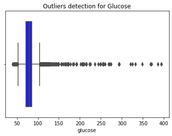

```python
# Checking for outliers
sns.boxplot(heart_data.glucose, color="blue");
plt.title('Outliers detection for Glucose')
plt.show()
```

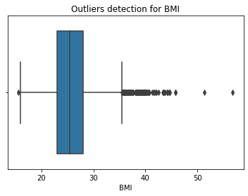

```python
# Check outliers for BMI
sns.boxplot(heart_data.BMI);
plt.title('Outliers detection for BMI')
plt.show()
```

## Data Exploration and Visualization

### Univariate Visualization

#### Pie chart on the Gender distribution

We are checking on the total gender distribution in our dataset. As seen in the Fig 1, the dataset has more women records compared to that of Men.

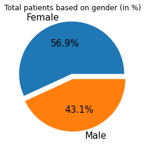

```python
#Pie-chart to check the gender distribution
test=[0.1,0]
heart_data.groupby('Gender').size().plot(kind='pie',
                                           title='Total patients based on gender (in %)',
                                           ylabel='',autopct='%1.1f%%', textprops={'fontsize': 15},explode=test)
plt.show()
```

#### Bar chart on the Education levels of the patients

We are checking on the education levels of all the patients. As seen in the Fig 2, majority of the patients are uneducated followed by the patients with primary level of education and then graduate and post graduate levels

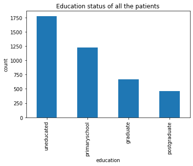

```python
# bar chart to explore total patients based on their education status
Education_levels = heart_data['education'].value_counts()
Education_levels.plot(kind='bar', title='Education status of all the patients',xlabel='education',ylabel='count')
plt.show()
```

#### Pie chart for patients with heart stroke

We are checking on the number of heart stroke patients. As seen in the Fig 3, more than half of the patients are not affected by heart stroke.

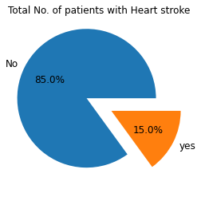

```python
# Pie chart to explore patients based on Heart stroke
test=[0.2,0.2]
heart_data.groupby('Heart_stroke').size().plot(kind='pie',
                                           title='Total No. of patients with Heart stroke',
                                           ylabel='',autopct='%1.1f%%', textprops={'fontsize': 12},explode=test)
plt.show()
```

#### Histogram on the Age distribution

We are checking on the age of all the patients in the dataset. As seen in Fig 4, there are patients ranging from an age of 30 to 70 years.

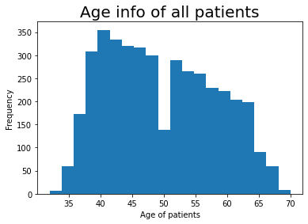

```python
# Histogram for Age info
heart_data['age'].plot(kind='hist', bins=20)
plt.title('Age info of all patients', fontdict={'fontsize':20})
plt.xlabel('Age of patients')
plt.show()
```

### Bivariate Visualization

#### Heart Stroke Vs Gender

We are checking on the heart stroke ratio with respect to the gender. As seen in Fig 5, from the given dataset it is clear that total count of female who had Heart stroke is lesser than that of Male.

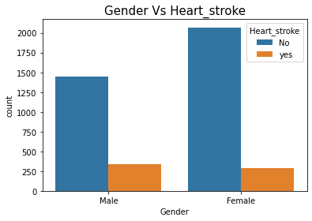

```python
plt.title('Gender Vs Heart_stroke', fontdict={'fontsize':15})
plot = sns.countplot(x='Gender', hue='Heart_stroke',data=heart_data)
```

#### Bar graph for comparing Diabetes Vs Heart Stroke

We are checking on the heart stroke ratio with respect to the Diabetic patients. As seen in Fig 6, from the given dataset it is clear that people who don't have diabetes have experienced heart stroke than who have diabetes.

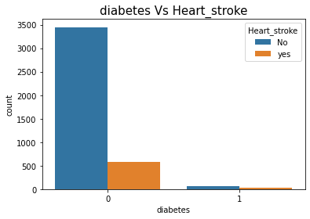

```python
plt.title('diabetes Vs Heart_stroke', fontdict={'fontsize':15})
plot = sns.countplot(x='diabetes', hue='Heart_stroke',data=heart_data)
```

#### Bar graph for comparing Current Smokers Vs Heart Stroke

We are checking on the heart stroke ratio with respect to the Current Smoker. As seen in Fig 7, from the given dataset it is clear that people who smoke and who don't have almost equally experienced heart stroke.

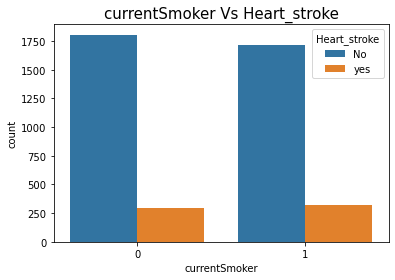

```python
plt.title('currentSmoker Vs Heart_stroke', fontdict={'fontsize':15})
plot = sns.countplot(x='currentSmoker', hue='Heart_stroke',data=heart_data)
```

#### Bar graph for comparing Prevalent Hypertension Vs Heart Stroke

We are checking on the heart stroke ratio with respect to the prevalent Hypertension. As seen in Fig 8, from the given dataset it is clear that people who have hypertension prevalence and who don't have almost equally experienced heart stroke.

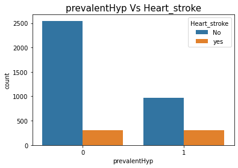

```python
plt.title('prevalentHyp Vs Heart_stroke', fontdict={'fontsize':15})
plot = sns.countplot(x='prevalentHyp', hue='Heart_stroke',data=heart_data)
```

### Multivariate Visualization

#### Cigarettes per day based on Age and Gender

We are checking further on the smoking habit where we checked on the cigarettes smoked per day by the smoking person with respect to their age and gender. As seen in Fig 9, though it appears that males smoke more number of cigarettes on any day when compared to females across their ages, there is no relation to the number of cigarettes with respect to the age.

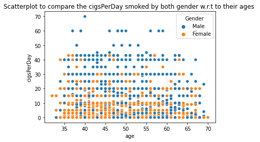

```python
# Catplot to show how currentsmoker and prevalentHyp vary based on Gender
sns.scatterplot(data=heart_data, x="age", y="cigsPerDay",
            hue="Gender").set(title='Scatterplot to compare the cigsPerDay smoked by both gender w.r.t to their ages ')
plt.show()
```

#### Heart stroke trend based on Age and Gender

We are checking on the Heart stroke with respect to the gender and Age of the person. As seen in Fig 10, it seems that the females suffered from heart stroke at later age than Male.

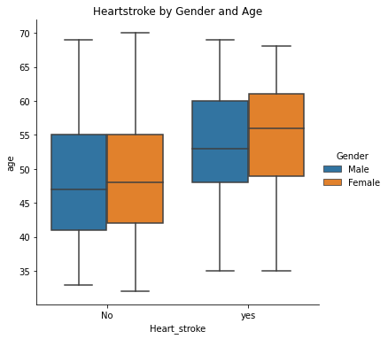

```python
# Catplot to show how heartstroke vary based on Gender and age
sns.catplot(data=heart_data, x="Heart_stroke", y="age",
            hue="Gender", kind="box").set(title='Heartstroke by Gender and Age')
plt.show()
```

#### Heart stroke based on the systolic and diastolic BP

We tried to understand if there is any dependencies between the BP observations and Heart stroke for a patient and as per the Fig 11 below it is observed that there is correlation between the systolic and diastolic BP readings and heart stroke is observed independent of these features.

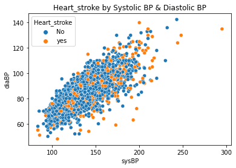

```python
sns.scatterplot(x='sysBP', y='diaBP', hue='Heart_stroke', data=heart_data).set(title='Heart_stroke by Systolic BP & Diastolic BP')
plt.show()
```

#### Heartstroke by Age and Glucose Levels

We are checking if there is any correlation between the heart stroke and the glucose level based on age, however as per fig 12 there is not much correlation observed with respect to the glucose levels and heart stroke.

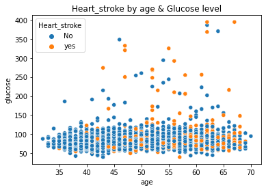

```python
sns.scatterplot(x='age', y='glucose', hue='Heart_stroke', data=heart_data).set(title='Heart_stroke by age & Glucose level')
plt.show()
```

## Summary and Conclusions

In Phase 1 of our project, we have taken a public heart disease dataset with the clinical features of the patients as the variables. Initially, we performed data preprocessing tasks like data cleaning, data processing, and visualizing the data. First, we have explored the variables and shape of the chosen dataset. While checking for null or missing values, we have found that variables like 'education', 'cigsPerDay', 'BPMeds', 'totChol', 'BMI', 'heartRate', and 'glucose' contains null values. We have replaced the null values with mode value, and mean value and dropped null values for few variables as shown above. Once after cleaning the data, we verified again whether the dataset still have any other missing values. We have also verified the dataset if it contains any duplicate/incorrect values. Besides, we have made data type conversions for 'cigsPerDay', and 'BPMeds'.

We will be exploring more about the dataset to perform tasks like Data preparation and implementing machine learning algorithms to the dataset to predict which clinical feature is the best predictor for heart stroke in Phase 2 of the project.

## Literature Review

Classification data represents one among the possible most popular jobs for machine learning techniques. The ability to extract information gathered from datasets of business activities and transmit it to broader databases seems to be crucial in this situation. The bulk underlying machine learning techniques rely on an enormous number of features to describe the behavior of the technique, which either directly or through inference increases the level of difficulty of any model being trained. However, Python's use in the field business health care is greatly benefited by the way it applies machine learning as well as artificial intelligence to help make meaning out of the statistics being analyzed.

Machine Learning's main objective is to construct systems, let them study, as well as then use what they learned to generate predictions. It builds a model by preparing machine learning techniques on a sample dataset. The system forecasts heart disease using the new incoming data. It creates models employing machine learning towards finding hidden correlations in the provided dataset. It generates precise forecasts for fresh datasets. Missing values are filled in once the dataset has been cleansed. The model forecasts heart disease using the new information provided, and its precision is subsequently evaluated.

By examining the risk factors of coronary artery disease via patient's data, it is possible to effectively predict the occurrence of heart attack. Methods for data mining are utilized across a variety of areas. Data mining was crucial in medical fields for predicting cardiac disease. For each condition to be diagnosed, doctors must do a variety of tests. However, heart disease detection cut down on work and produced reliable findings.

BMI may be linked to an increased risk of developing heart disease in general. However, a lot of research only appear to address the issue in more generic ways. A connection involving heart attacks or BMI has been shown in earlier observational studies. They looked at 899 obese people among the ages of 35–74. The researchers came to the conclusion that being overweight or obese was neither an independently observed standalone cardiovascular risk indicator after ten years of monitoring. Due to the limited sample magnitude, this research's statistical strength is inadequate. Additionally, similar to other empirical investigations, it may have confounding issues (such as cigarette and liquor usage) and other forms of bias. Outcomes of these investigations are of limited relevance since clinical therapy development need the identification of precise causative elements.

AMI (Acute Myocardial Infarction) was subsequently detected in a significant fraction of patients, especially approximately half of those women, who refused to initially complain of discomfort in their chests. The majority of the gendered disparities in presentation, especially in children and adolescents, are explained by the existence of co-morbid illnesses, which reduce the probability that chest pain would be the primary complaint.

These findings imply that tobacco use is an essential component in the connection between periodontal gum disease as well as heart attacks and strokes, and the chance of developing it is believed to grow with age. It is challenging to evaluate what percentage of the observed connection was caused by periodontist diseases, though, given the significant role smoking plays in the aetiology of both restoration and cardiac illnesses.

Studies have supported the association between greater BMI along with a higher perceived risk of mellitus alongside heart attack as well as any family background of diabetes or an early heart attack. A few subjects reported a twofold risk of developing diabetes or cardiac arrest despite similar risk factors, although age along with physical fitness were not related to both risk perception. Proper assessment of one's risk due to diabetes as well as cardiovascular disease is the crucial initial step in making these lifestyle adjustments, but preventing diabetic complications and heart attacks demands drive and dedication. Health care professionals must evaluate the differences between person's perceived risk as well as the lack of actual danger indicators and educate patients about the link between being diabetic and getting heart attacks.

### References

- Mirza_Hasnine. (2023, March 11). Heart disease dataset. Kaggle. Retrieved April 5, 2023, from https://www.kaggle.com/datasets/mirzahasnine/heart-disease-dataset
- Chang, V., Bhavani, V., Xu, A., & Hossain, M. (2022, January 31). An artificial intelligence model for heart disease detection using machine learning algorithms. Retrieved April 9, 2023, from https://www.sciencedirect.com/science/article/pii/S2772442522000016
- Shah, D., Patel, S., & Bharti, S. (2020, October 16). Heart disease prediction using machine learning techniques - SN computer science. Retrieved April 9, 2023, from https://link.springer.com/article/10.1007/s42979-020-00365-y
- Solanki, Y., & Sharma, S. (2019, July 18). A survey on risk assessments of heart attack using data mining approaches. Retrieved April 9, 2023, from https://hal.science/hal-02188879/
- Adams, B., Jacocks, L., & Guo, H. (2020, May 29). Higher BMI is linked to an increased risk of heart attacks in European adults: A mendelian randomisation study - BMC cardiovascular disorders. Retrieved April 9, 2023, from https://bmccardiovascdisord.biomedcentral.com/articles/10.1186/s12872-020-01542-w
- Kerry A. Milner DNSc. (2004, February 25). Gender and age differences in chief complaints of acute myocardial infarction (worcester heart attack study). Retrieved April 9, 2023, from https://www.sciencedirect.com/science/article/pii/S0002914903016576
- Hariri, S., & Bender, M. (2015, April 20). Family history and body mass index predict perceived risks of diabetes and heart attack among community-dwelling Caucasian, Filipino, Korean, and Latino Americans-dilh survey. Retrieved April 9, 2023, from https://www.sciencedirect.com/science/article/pii/S0168822715001977